# Project 07: Burrows-Wheeler Transform

# Learning Objectives

1. Students will be able to explain the fundamental principles of the Burrows-Wheeler Transform algorithm, including its purpose, process, and applications in data compression and bioinformatics.
2. Students will be able to implement the Burrows-Wheeler Transform using both the naive approach and the more efficient suffix array method.
3. Students will be able to construct auxiliary data structures (count array and occurrence array) needed for efficient pattern matching with the FM-Index.
4. Students will be able to apply the BWT-based pattern matching algorithm to find exact string matches within a reference text.

# Background

The Burrows-Wheeler Transform (BWT) is a powerful algorithm used in data compression and bioinformatics. Developed by Michael Burrows and David Wheeler in 1994, it rearranges a character string into runs of similar characters, making it more amenable to compression techniques like move-to-front encoding and run-length encoding. Despite adding a small amount of overhead, BWT’s ability to group similar characters together significantly improves compression efficiency.

The BWT works by sorting all possible rotations of a string lexicographically and then extracting the last column of the sorted matrix. What makes BWT remarkable is that this transformation is reversible without storing much additional information - only the position of the original string in the sorted rotations is needed.

In recent years, BWT has found extensive applications beyond compression. It’s particularly valuable in bioinformatics for efficient sequence alignment of DNA reads against reference genomes, as implemented in popular tools like Bowtie and BWA. The algorithm’s efficiency in handling large datasets has made it indispensable for processing the massive amounts of data generated by next-generation sequencing technologies.

# The BWT Algorithm

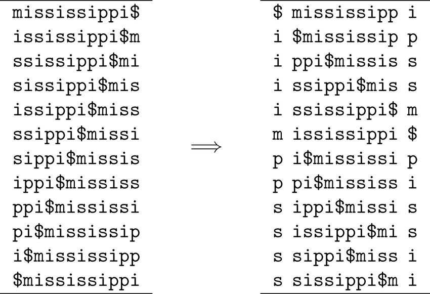

> Credit: Ferragina, P., Giancarlo, R., Manzini, G., & Sciortino, M. (2005). Boosting textual compression in optimal linear time. In Journal of the ACM (Vol. 52, Issue 4, pp. 688–713). Association for Computing Machinery (ACM). https://doi.org/10.1145/1082036.1082043

At its core, the BWT algorithm involves creating all cyclic rotations of an input string, sorting them lexicographically, and then extracting the last column.

Let’s define the pseudocode for our BWT function:

> $${\small
> \begin{array}{l}
> \textbf{function } \text{BWT}(text) \\
> \quad \text{Append a unique end-of-string character to } text \text{ if
> not present} \\
> \quad \text{Create a list to store all possible rotations of the text}
> \\
> \quad \textbf{for each } \text{possible starting position in the text}
> \textbf{ do} \\
> \quad\quad \text{Generate a rotation starting at this position and add
> to the list} \\
> \quad \text{Sort all rotations lexicographically} \\
> \quad \text{Initialize an empty string for the transformed result} \\
> \quad \textbf{for each } \text{rotation in the sorted list} \textbf{ do}
> \\
> \quad\quad \text{Append the last character of this rotation to the
> transformed result} \\
> \quad \textbf{return } \text{transformed result and position of original
> text in sorted rotations}
> \end{array}
> }$$

```python
def BWT(string: str) -> str:
    """Function to calculate Burrows-Wheeler Transform for a given string.

    Computes the Burrows-Wheeler Transform by creating all rotations of the input
    string, sorting them lexicographically, and extracting the last column.

    Args:
        string: The input string to transform.

    Returns:
        The Burrows-Wheeler Transform of the input string.

    Examples:
        >>> BWT('googol')
        'lo$oogg'

        >>> BWT('banana$')
        'annb$aa'
    """
    pass
```

While this approach works, it’s inefficient for large strings. A more efficient implementation uses suffix arrays.

# Suffix Arrays for BWT

Suffix arrays provide a memory-efficient way to compute the BWT. A suffix array contains the starting positions of all suffixes of a string, sorted lexicographically.

> $${\small
> \begin{array}{l}
> \textbf{function } \text{suffix_array}(text) \\
> \quad \text{Create a list of all suffixes of the text, each paired with
> its starting position} \\
> \quad \text{Sort these suffix-position pairs lexicographically by
> suffix} \\
> \quad \text{Extract just the starting positions from the sorted pairs}
> \\
> \quad \textbf{return } \text{the list of sorted starting positions}
> \end{array}
> }$$

```python
def suffix_array(string: str) -> list[int]:
    """Function to calculate suffix-array for a given string.

    Computes the suffix array by sorting all suffixes of the input string
    lexicographically and returning their starting positions.

    Args:
        string: The input string to process.

    Returns:
        A list of integers representing the starting positions of the
        lexicographically sorted suffixes.

    Examples:
        >>> suffix_array('googol')
        [6, 3, 0, 5, 2, 4, 1]

        >>> suffix_array('banana$')
        [6, 5, 3, 1, 0, 4, 2]
    """
    pass
```

Once we have the suffix array, we can compute the BWT more efficiently:

> $${\small
> \begin{array}{l}
> \textbf{function } \text{BWT_from_suffix_array}(text, > \text{suffix
> positions}) \\
> \quad \text{Initialize an empty string of the same length as the input
> text} \\
> \quad \textbf{for each } \text{position in the suffix positions list}
> \textbf{ do} \\
> \quad\quad \textbf{if } \text{the suffix starts at the beginning of the
> text} \textbf{ then} \\
> \quad\quad\quad \text{Add the last character of the text to the
> transformed result} \\
> \quad\quad \textbf{else} \\
> \quad\quad\quad \text{Add the character preceding the suffix to the
> transformed result} \\
> \quad \textbf{return } \text{the transformed result}
> \end{array}
> }$$

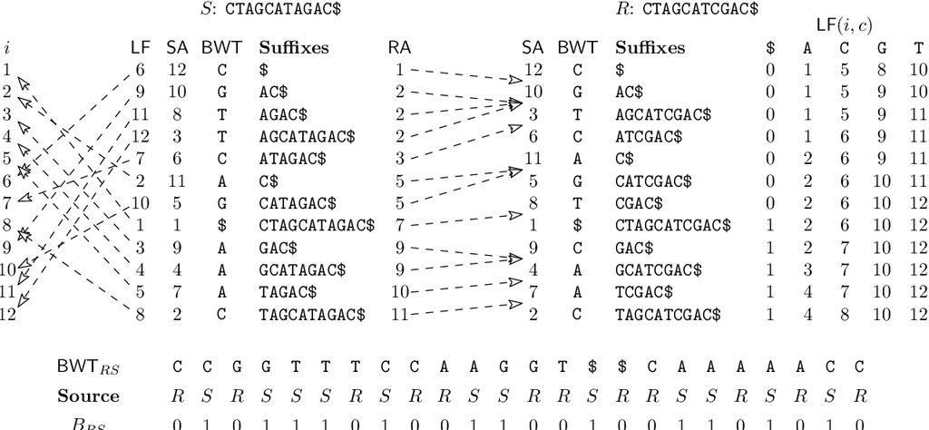

> Credit: Siren, J. (2016). Burrows-Wheeler Transform for Terabases. In 2016 Data Compression Conference (DCC) (pp. 211–220). 2016 Data Compression Conference (DCC). IEEE. https://doi.org/10.1109/dcc.2016.17

```python
def BWT_from_suffix_array(
  text: str,
  suffix_positions: list[int]
  ) -> str:
    """Function to calculate the Burrows-Wheeler Transform from a suffix array.

    Computes the Burrows-Wheeler Transform by using the suffix array to identify
    the character that precedes each suffix in the sorted order.

    Args:
        text: The input string to transform.
        suffix_positions: The suffix array for the input string, containing the
            starting positions of all suffixes in lexicographical order.

    Returns:
        The Burrows-Wheeler Transform of the input string.

    Examples:
        >>> BWT_from_suffix_array("banana$", [6, 5, 3, 1, 0, 4, 2])
        'annb$aa'

        >>> BWT_from_suffix_array("googol$", [6, 3, 0, 5, 2, 4, 1])
        'lo$oogg'
    """
    pass
```